# Assignment 2

Zeenat Nazir

Date created: 2019-05-01

**CHEATSHEETS**

1. [Data visualization](https://github.com/rstudio/cheatsheets/blob/master/data-visualization-2.1.pdf)
2. [Data Manipulation](https://github.com/rstudio/cheatsheets/blob/master/data-transformation.pdf)

Create a new notebook (copy parts of the YAML header you are interested in keeping) to work on your assignment. The assignment should be submitted via a shareable github link that points to your notebook (.nb.html) file to me on Slack. Make sure the notebook is neatly formatted, and that all the charts and tables and look good when you preview it. Task: Explore at least 5 different causes for departure and arrival delays (combined - not 5 each). Its not necessary that you find a definitive answer for what causes a delay, instead I want you to showcase your ability to explore the data with a combination of analytical text, tables and charts. The final output should be something you can show a prospective employer or client as proof of you ability to work with data in R.

## Loading and installing relevant packages for this assignment

```r
library(tidyverse); library(nycflights13); library(skimr); library(timeDate); library(ggthemes)
#install.packages("timeDate")
#install.packages("lubridate")
library(lubridate)
```

## Viewing all the datasets in nycflights

```r
flights
```

| year | month | day | dep_time | sched_dep_time | dep_delay | arr_time | sched_arr_time | arr_delay | carrier | flight | tailnum | origin | dest | air_time | distance | hour | minute | time_hour |
| --- | --- | --- | --- | --- | --- | --- | --- | --- | --- | --- | --- | --- | --- | --- | --- | --- | --- | --- |
| 2013 | 1 | 1 | 517 | 515 | 2 | 830 | 819 | 11 | UA | 1545 | N14228 | EWR | IAH | 227 | 1400 | 5 | 15 | 2013-01-01 05:00:00 |
| 2013 | 1 | 1 | 533 | 529 | 4 | 850 | 830 | 20 | UA | 1714 | N24211 | LGA | IAH | 227 | 1416 | 5 | 29 | 2013-01-01 05:00:00 |
| 2013 | 1 | 1 | 542 | 540 | 2 | 923 | 850 | 33 | AA | 1141 | N619AA | JFK | MIA | 160 | 1089 | 5 | 40 | 2013-01-01 05:00:00 |
| 2013 | 1 | 1 | 544 | 545 | -1 | 1004 | 1022 | -18 | B6 | 725 | N804JB | JFK | BQN | 183 | 1576 | 5 | 45 | 2013-01-01 05:00:00 |
| 2013 | 1 | 1 | 554 | 600 | -6 | 812 | 837 | -25 | DL | 461 | N668DN | LGA | ATL | 116 | 762 | 6 | 0 | 2013-01-01 06:00:00 |
| 2013 | 1 | 1 | 554 | 558 | -4 | 740 | 728 | 12 | UA | 1696 | N39463 | EWR | ORD | 150 | 719 | 5 | 58 | 2013-01-01 05:00:00 |
| 2013 | 1 | 1 | 555 | 600 | -5 | 913 | 854 | 19 | B6 | 507 | N516JB | EWR | FLL | 158 | 1065 | 6 | 0 | 2013-01-01 06:00:00 |
| 2013 | 1 | 1 | 557 | 600 | -3 | 709 | 723 | -14 | EV | 5708 | N829AS | LGA | IAD | 53 | 229 | 6 | 0 | 2013-01-01 06:00:00 |
| 2013 | 1 | 1 | 557 | 600 | -3 | 838 | 846 | -8 | B6 | 79 | N593JB | JFK | MCO | 140 | 944 | 6 | 0 | 2013-01-01 06:00:00 |
| 2013 | 1 | 1 | 558 | 600 | -2 | 753 | 745 | 8 | AA | 301 | N3ALAA | LGA | ORD | 138 | 733 | 6 | 0 | 2013-01-01 06:00:00 |

[output cut: 990 more lines]

```r
weather
```

| origin | year | month | day | hour | temp | dewp | humid | wind_dir | wind_speed | wind_gust | precip | pressure | visib | time_hour |
| --- | --- | --- | --- | --- | --- | --- | --- | --- | --- | --- | --- | --- | --- | --- |
| EWR | 2013 | 1 | 1 | 1 | 39.02 | 26.06 | 59.37 | 270 | 10.35702 | NA | 0.00 | 1012.0 | 10.00 | 2013-01-01 01:00:00 |
| EWR | 2013 | 1 | 1 | 2 | 39.02 | 26.96 | 61.63 | 250 | 8.05546 | NA | 0.00 | 1012.3 | 10.00 | 2013-01-01 02:00:00 |
| EWR | 2013 | 1 | 1 | 3 | 39.02 | 28.04 | 64.43 | 240 | 11.50780 | NA | 0.00 | 1012.5 | 10.00 | 2013-01-01 03:00:00 |
| EWR | 2013 | 1 | 1 | 4 | 39.92 | 28.04 | 62.21 | 250 | 12.65858 | NA | 0.00 | 1012.2 | 10.00 | 2013-01-01 04:00:00 |
| EWR | 2013 | 1 | 1 | 5 | 39.02 | 28.04 | 64.43 | 260 | 12.65858 | NA | 0.00 | 1011.9 | 10.00 | 2013-01-01 05:00:00 |
| EWR | 2013 | 1 | 1 | 6 | 37.94 | 28.04 | 67.21 | 240 | 11.50780 | NA | 0.00 | 1012.4 | 10.00 | 2013-01-01 06:00:00 |
| EWR | 2013 | 1 | 1 | 7 | 39.02 | 28.04 | 64.43 | 240 | 14.96014 | NA | 0.00 | 1012.2 | 10.00 | 2013-01-01 07:00:00 |
| EWR | 2013 | 1 | 1 | 8 | 39.92 | 28.04 | 62.21 | 250 | 10.35702 | NA | 0.00 | 1012.2 | 10.00 | 2013-01-01 08:00:00 |
| EWR | 2013 | 1 | 1 | 9 | 39.92 | 28.04 | 62.21 | 260 | 14.96014 | NA | 0.00 | 1012.7 | 10.00 | 2013-01-01 09:00:00 |
| EWR | 2013 | 1 | 1 | 10 | 41.00 | 28.04 | 59.65 | 260 | 13.80936 | NA | 0.00 | 1012.4 | 10.00 | 2013-01-01 10:00:00 |

[output cut: 990 more lines]

```r
  #skim(weather)
```

```r
airports
```

| faa | name | lat | lon | alt | tz | dst | tzone |
| --- | --- | --- | --- | --- | --- | --- | --- |
| 04G | Lansdowne Airport | 41.13047 | -80.61958 | 1044 | -5 | A | America/New_York |
| 06A | Moton Field Municipal Airport | 32.46057 | -85.68003 | 264 | -6 | A | America/Chicago |
| 06C | Schaumburg Regional | 41.98934 | -88.10124 | 801 | -6 | A | America/Chicago |
| 06N | Randall Airport | 41.43191 | -74.39156 | 523 | -5 | A | America/New_York |
| 09J | Jekyll Island Airport | 31.07447 | -81.42778 | 11 | -5 | A | America/New_York |
| 0A9 | Elizabethton Municipal Airport | 36.37122 | -82.17342 | 1593 | -5 | A | America/New_York |
| 0G6 | Williams County Airport | 41.46731 | -84.50678 | 730 | -5 | A | America/New_York |
| 0G7 | Finger Lakes Regional Airport | 42.88356 | -76.78123 | 492 | -5 | A | America/New_York |
| 0P2 | Shoestring Aviation Airfield | 39.79482 | -76.64719 | 1000 | -5 | U | America/New_York |
| 0S9 | Jefferson County Intl | 48.05381 | -122.81064 | 108 | -8 | A | America/Los_Angeles |

[output cut: 990 more lines]

```r
#skim(airports)
```

```r
airlines
```

| carrier | name |
| --- | --- |
| 9E | Endeavor Air Inc. |
| AA | American Airlines Inc. |
| AS | Alaska Airlines Inc. |
| B6 | JetBlue Airways |
| DL | Delta Air Lines Inc. |
| EV | ExpressJet Airlines Inc. |
| F9 | Frontier Airlines Inc. |
| FL | AirTran Airways Corporation |
| HA | Hawaiian Airlines Inc. |
| MQ | Envoy Air |

[output cut: 6 more lines]

```r
planes
```

| tailnum | year | type | manufacturer | model | engines | seats | speed | engine |
| --- | --- | --- | --- | --- | --- | --- | --- | --- |
| N10156 | 2004 | Fixed wing multi engine | EMBRAER | EMB-145XR | 2 | 55 | NA | Turbo-fan |
| N102UW | 1998 | Fixed wing multi engine | AIRBUS INDUSTRIE | A320-214 | 2 | 182 | NA | Turbo-fan |
| N103US | 1999 | Fixed wing multi engine | AIRBUS INDUSTRIE | A320-214 | 2 | 182 | NA | Turbo-fan |
| N104UW | 1999 | Fixed wing multi engine | AIRBUS INDUSTRIE | A320-214 | 2 | 182 | NA | Turbo-fan |
| N10575 | 2002 | Fixed wing multi engine | EMBRAER | EMB-145LR | 2 | 55 | NA | Turbo-fan |
| N105UW | 1999 | Fixed wing multi engine | AIRBUS INDUSTRIE | A320-214 | 2 | 182 | NA | Turbo-fan |
| N107US | 1999 | Fixed wing multi engine | AIRBUS INDUSTRIE | A320-214 | 2 | 182 | NA | Turbo-fan |
| N108UW | 1999 | Fixed wing multi engine | AIRBUS INDUSTRIE | A320-214 | 2 | 182 | NA | Turbo-fan |
| N109UW | 1999 | Fixed wing multi engine | AIRBUS INDUSTRIE | A320-214 | 2 | 182 | NA | Turbo-fan |
| N110UW | 1999 | Fixed wing multi engine | AIRBUS INDUSTRIE | A320-214 | 2 | 182 | NA | Turbo-fan |

[output cut: 990 more lines]

## Merging the weather, airlines and flights datasets.

#### *Ignoring airports for the purpose of this assignment. Starting with a full merged dataset (and narrow down later by hypothesis).

### We start first by exploring keys for different datasets

```r
#This is exploring keys to merge weather to flights and the other relevant datasets
weather %>%
  group_by(time_hour, origin) %>%
  #summarise(nobs = n()) #This is just to explore how many obs (count) per group
  filter(n() > 1)
```

| origin | year | month | day | hour | temp | dewp | humid | wind_dir | wind_speed | wind_gust | precip | pressure | visib | time_hour |
| --- | --- | --- | --- | --- | --- | --- | --- | --- | --- | --- | --- | --- | --- | --- |

```r
#This is exploring keys to merge planes to flights and the other relevant datasets
planes %>%
  group_by(tailnum) %>%
  #summarise(nobs = n()) #This is just to explore how many obs (count) per group
  filter(n() > 1)
```

| tailnum | year | type | manufacturer | model | engines | seats | speed | engine |
| --- | --- | --- | --- | --- | --- | --- | --- | --- |

### Merging weather and airlines and planes to flights with established keys

```r
weatheredFlights <- flights %>%
  left_join(weather, by = c("origin", "time_hour")) %>%
  left_join(airlines, by = c("carrier")) %>%
  left_join(planes, by = c("tailnum"))
  weatheredFlights
```

| year.x | month.x | day.x | dep_time | sched_dep_time | dep_delay | arr_time | sched_arr_time | arr_delay | carrier | flight | tailnum | origin | dest | air_time | distance | hour.x | minute | time_hour | year.y | month.y | day.y | hour.y | temp | dewp | humid | wind_dir | wind_speed | wind_gust | precip | … |
| --- | --- | --- | --- | --- | --- | --- | --- | --- | --- | --- | --- | --- | --- | --- | --- | --- | --- | --- | --- | --- | --- | --- | --- | --- | --- | --- | --- | --- | --- | --- |
| 2013 | 1 | 1 | 517 | 515 | 2 | 830 | 819 | 11 | UA | 1545 | N14228 | EWR | IAH | 227 | 1400 | 5 | 15 | 2013-01-01 05:00:00 | 2013 | 1 | 1 | 5 | 39.02 | 28.04 | 64.43 | 260 | 12.65858 | NA | 0 | … |
| 2013 | 1 | 1 | 533 | 529 | 4 | 850 | 830 | 20 | UA | 1714 | N24211 | LGA | IAH | 227 | 1416 | 5 | 29 | 2013-01-01 05:00:00 | 2013 | 1 | 1 | 5 | 39.92 | 24.98 | 54.81 | 250 | 14.96014 | 21.86482 | 0 | … |
| 2013 | 1 | 1 | 542 | 540 | 2 | 923 | 850 | 33 | AA | 1141 | N619AA | JFK | MIA | 160 | 1089 | 5 | 40 | 2013-01-01 05:00:00 | 2013 | 1 | 1 | 5 | 39.02 | 26.96 | 61.63 | 260 | 14.96014 | NA | 0 | … |
| 2013 | 1 | 1 | 544 | 545 | -1 | 1004 | 1022 | -18 | B6 | 725 | N804JB | JFK | BQN | 183 | 1576 | 5 | 45 | 2013-01-01 05:00:00 | 2013 | 1 | 1 | 5 | 39.02 | 26.96 | 61.63 | 260 | 14.96014 | NA | 0 | … |
| 2013 | 1 | 1 | 554 | 600 | -6 | 812 | 837 | -25 | DL | 461 | N668DN | LGA | ATL | 116 | 762 | 6 | 0 | 2013-01-01 06:00:00 | 2013 | 1 | 1 | 6 | 39.92 | 24.98 | 54.81 | 260 | 16.11092 | 23.01560 | 0 | … |
| 2013 | 1 | 1 | 554 | 558 | -4 | 740 | 728 | 12 | UA | 1696 | N39463 | EWR | ORD | 150 | 719 | 5 | 58 | 2013-01-01 05:00:00 | 2013 | 1 | 1 | 5 | 39.02 | 28.04 | 64.43 | 260 | 12.65858 | NA | 0 | … |
| 2013 | 1 | 1 | 555 | 600 | -5 | 913 | 854 | 19 | B6 | 507 | N516JB | EWR | FLL | 158 | 1065 | 6 | 0 | 2013-01-01 06:00:00 | 2013 | 1 | 1 | 6 | 37.94 | 28.04 | 67.21 | 240 | 11.50780 | NA | 0 | … |
| 2013 | 1 | 1 | 557 | 600 | -3 | 709 | 723 | -14 | EV | 5708 | N829AS | LGA | IAD | 53 | 229 | 6 | 0 | 2013-01-01 06:00:00 | 2013 | 1 | 1 | 6 | 39.92 | 24.98 | 54.81 | 260 | 16.11092 | 23.01560 | 0 | … |
| 2013 | 1 | 1 | 557 | 600 | -3 | 838 | 846 | -8 | B6 | 79 | N593JB | JFK | MCO | 140 | 944 | 6 | 0 | 2013-01-01 06:00:00 | 2013 | 1 | 1 | 6 | 37.94 | 26.96 | 64.29 | 260 | 13.80936 | NA | 0 | … |
| 2013 | 1 | 1 | 558 | 600 | -2 | 753 | 745 | 8 | AA | 301 | N3ALAA | LGA | ORD | 138 | 733 | 6 | 0 | 2013-01-01 06:00:00 | 2013 | 1 | 1 | 6 | 39.92 | 24.98 | 54.81 | 260 | 16.11092 | 23.01560 | 0 | … |

[output cut: 990 more lines]

## Formulating initial hypotheses for causes of arrival and departure delays

- **Question 1: Is there a relationship between the carrier you fly and delays. That is, do certain airlines have a track record of departure delays?**

### Examining data sources and independent var

```r
weatheredFlights %>%
names()
```

```
 [1] "year.x"         "month.x"        "day.x"          "dep_time"       "sched_dep_time" "dep_delay"      "arr_time"
 [8] "sched_arr_time" "arr_delay"      "carrier"        "flight"         "tailnum"        "origin"         "dest"
[15] "air_time"       "distance"       "hour.x"         "minute"         "time_hour"      "year.y"         "month.y"
[22] "day.y"          "hour.y"         "temp"           "dewp"           "humid"          "wind_dir"       "wind_speed"
[29] "wind_gust"      "precip"         "pressure"       "visib"          "name"           "year"           "type"
[36] "manufacturer"   "model"          "engines"        "seats"          "speed"          "engine"
```

```r
weatheredFlights %>%
  filter(dep_delay > 0) %>%
  group_by(name) %>%
  count(name) %>%
  arrange(n)
```

| name | n |
| --- | --- |
| SkyWest Airlines Inc. | 9 |
| Hawaiian Airlines Inc. | 69 |
| Alaska Airlines Inc. | 226 |
| Mesa Airlines Inc. | 233 |
| Frontier Airlines Inc. | 341 |
| AirTran Airways Corporation | 1654 |
| Virgin America | 2225 |
| US Airways Inc. | 4775 |
| Southwest Airlines Co. | 6558 |
| Endeavor Air Inc. | 7063 |

[output cut: 6 more lines]

### Examining avg departure delay by carrier

```
Ignoring unknown parameters: stat
```

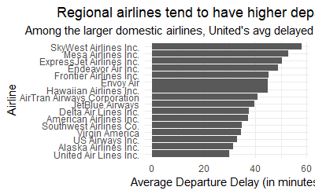

```r
weatheredFlights %>%
  filter(dep_delay > 0) %>%
  group_by(name) %>%
  summarise(meanDelay = mean(dep_delay, na.rm = T)) %>%
  arrange(desc(meanDelay)) %>%
  ggplot(aes(x = reorder(name, meanDelay), y = meanDelay)) +
  geom_col(stat = 'identity') +
  coord_flip() +
    labs(
    x = "Airline",
    y = "Average Departure Delay (in minutes)",
    title = "Regional airlines tend to have higher departure delays",
    subtitle = "Among the larger domestic airlines, United's avg delayed departures are lowest"
  ) +
  theme_minimal() +
  theme(plot.title = element_text(hjust = 0.5), plot.subtitle = element_text(hjust = 0.5))
```

- **Question 2: Which days (if any) of the week have higher departure delays and if so, which airports have relatively high dep delays?**

### Identifying and using the right variable to extract day of the week. And then summarising dep delays by day of the week. Question for Hari - how do I reverse the appearance of the legend such that LGA is top and EWR bottom to more cleanly align with the bars?

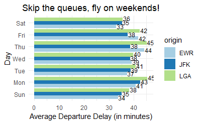

```r
weatheredFlights %>%
mutate(date = as.Date(time_hour)) %>%
mutate(dayofweek = wday(date, label = TRUE)) %>%
  filter(dep_delay > 0) %>%
  group_by(dayofweek, origin) %>%
  summarise(meanDelay = mean(dep_delay, na.rm = T)) %>%
  arrange(desc(meanDelay)) %>%
  ggplot(aes(dayofweek, meanDelay, fill = origin)) +
   geom_bar(stat = 'identity', position=position_dodge()) +
   geom_text(aes(label= round(meanDelay)), vjust=0.4, color="black", hjust = -0.05,
            position = position_dodge(1), size=3.2) +
  scale_fill_brewer(palette= "Paired") +
    coord_flip() +
    labs(
    x = "Day",
    y = "Average Departure Delay (in minutes)",
    title = "Skip the queues, fly on weekends!"
    ) +
  theme_minimal() +
  theme(plot.title = element_text(hjust = 0.5), plot.subtitle = element_text(hjust = 0.5))
```

- **Question 3: Does visibility (along with precipitation) affect dep delays?**

### Exploring the visibility var

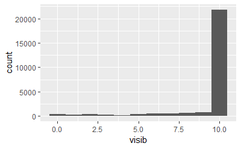

```r
weather %>%
  ggplot(aes(visib)) +
  geom_histogram(binwidth = 1)
```

### Exploring the precip var

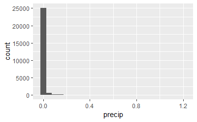

```r
weather %>%
  ggplot(aes(precip)) +
  geom_histogram(binwidth = 0.05)
```

### Exploring how visibility alone relates to delay

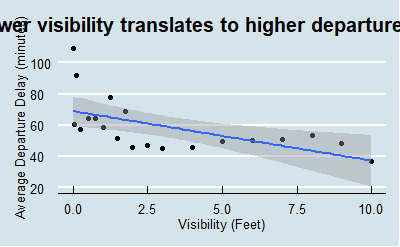

```r
#Explore how visibility relates to delay
weatheredFlights %>%
  filter(dep_delay > 0 & !is.na(dep_delay) & !is.na(visib)) %>%
  group_by(visib) %>%
  summarise(meanDelay = mean(dep_delay, na.rm = T)) %>%
  ggplot(aes(visib, meanDelay))+
  geom_point() +
    geom_smooth(method = "lm") +
  #panel.background = element_rect(fill = NA) +
    labs(
    x = "Visibility (Feet)",
    y = "Average Departure Delay (minutes)",
    title = "Lower visibility translates to higher departure delays"
    ) +
  theme_economist() +
  theme(plot.title = element_text(hjust = 0.5), plot.subtitle = element_text(hjust = 0.5))
```

### Exploring how visibility along with precipitation relates to delay. Question for Hari - how do I add label to visib? Also, how do I get both visib groups into the same chart with different colors and lines.

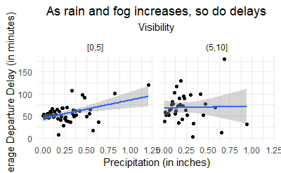

```r
#Let's explore how precip and visibility relate to delay
weatheredFlights %>%
  filter(dep_delay > 0 & !is.na(dep_delay) & !is.na(temp) & !is.na(visib)) %>%
  mutate(visibGroup = cut_interval(visib, length = 5, na.rm = T)) %>%
  group_by(precip, visibGroup) %>%
  summarise(meanDelay = mean(dep_delay, na.rm = T)) %>%
  ggplot(aes(precip, meanDelay))+
  geom_point() +
    geom_smooth(method = "lm") +
    facet_wrap(~visibGroup) +
      labs(
    x = "Precipitation (in inches)",
    y = "Average Departure Delay (in minutes)",
    title = "As rain and fog increases, so do delays",
    subtitle = "Visibility"
    ) +
  theme_minimal() +
  theme(plot.title = element_text(hjust = 0.5), plot.subtitle = element_text(hjust = 0.5))
```

+**Question 4: Does the volume of flights on any given day affect delays?** Hari - this was a very roundabout way of doing this. Would appreciate thoughts on a simpler solution.

```r
# Creating a variable called depDate in order to create another variable containing number of flights per depDate called flightVol. Then summarising to create a mean delay var grouped by depDate. Saving this to a tibble
depdatemeandel <- weatheredFlights %>%
  mutate(depDate = paste(year.x, month.x, day.x, sep = "-")) %>%
  group_by(depDate) %>%
  mutate(flightVol = n()) %>%
  filter(dep_delay > 0 & !is.na(dep_delay) & !is.na(depDate)) %>%
  summarise(meanDelay = mean(dep_delay, na.rm = T))
depdatemeandel
```

| depDate | meanDelay |
| --- | --- |
| 2013-1-1 | 32.66477 |
| 2013-1-10 | 32.61257 |
| 2013-1-11 | 25.30802 |
| 2013-1-12 | 20.78613 |
| 2013-1-13 | 49.97245 |
| 2013-1-14 | 24.99167 |
| 2013-1-15 | 23.45732 |
| 2013-1-16 | 44.56461 |
| 2013-1-17 | 29.94637 |
| 2013-1-18 | 27.76677 |

[output cut: 355 more lines]

```r
# Creating again just a tibble like above without summarising mean delay. calling it fightvoltibble
flightvoltibble <- weatheredFlights %>%
  mutate(depDate = paste(year.x, month.x, day.x, sep = "-")) %>%
  group_by(depDate) %>%
  mutate(flightVol = n()) %>%
  select(depDate, flightVol)
flightvoltibble
```

| depDate | flightVol |
| --- | --- |
| 2013-1-1 | 842 |
| 2013-1-1 | 842 |
| 2013-1-1 | 842 |
| 2013-1-1 | 842 |
| 2013-1-1 | 842 |
| 2013-1-1 | 842 |
| 2013-1-1 | 842 |
| 2013-1-1 | 842 |
| 2013-1-1 | 842 |
| 2013-1-1 | 842 |

[output cut: 990 more lines]

```r
# Finally, joining these 2 tibbles and then extracting only distinct values for each depdate
newqfourtibble <- depdatemeandel %>%
  left_join(flightvoltibble, by = c("depDate")) %>%
  distinct()
  newqfourtibble
```

| depDate | meanDelay | flightVol |
| --- | --- | --- |
| 2013-1-1 | 32.66477 | 842 |
| 2013-1-10 | 32.61257 | 932 |
| 2013-1-11 | 25.30802 | 930 |
| 2013-1-12 | 20.78613 | 690 |
| 2013-1-13 | 49.97245 | 828 |
| 2013-1-14 | 24.99167 | 928 |
| 2013-1-15 | 23.45732 | 894 |
| 2013-1-16 | 44.56461 | 901 |
| 2013-1-17 | 29.94637 | 927 |
| 2013-1-18 | 27.76677 | 924 |

[output cut: 355 more lines]

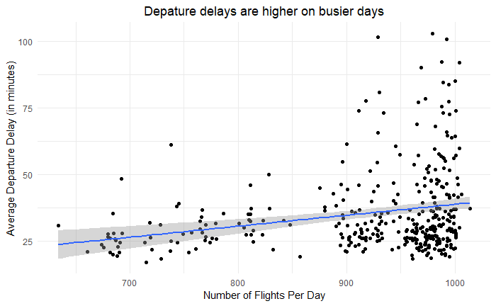

```r
 # Plotting flightvol against meandelay
  newqfourtibble %>%
    ggplot(aes(flightVol, meanDelay))+
  geom_point() +
    geom_smooth(method = "lm") +
    #facet_wrap(~visibGroup) +
      labs(
    x = "Number of Flights Per Day",
    y = "Average Departure Delay (in minutes)",
    title = "Depature delays are higher on busier days"
    ) +
  theme_minimal() +
  theme(plot.title = element_text(hjust = 0.5), plot.subtitle = element_text(hjust = 0.5))
```